# HW2 - Do Households Value Transit-rich Neighborhoods compared to Others in Boston?

The following figure shows the proportion of white population by tract in Boston. In the Boston area and the northern and southwestern parts of Suffolk County, the difference in white population between TOD and non-TOD areas was not large, while in the central and southern parts of Suffolk County, the difference in white population between TOD and non-TOD areas was large.

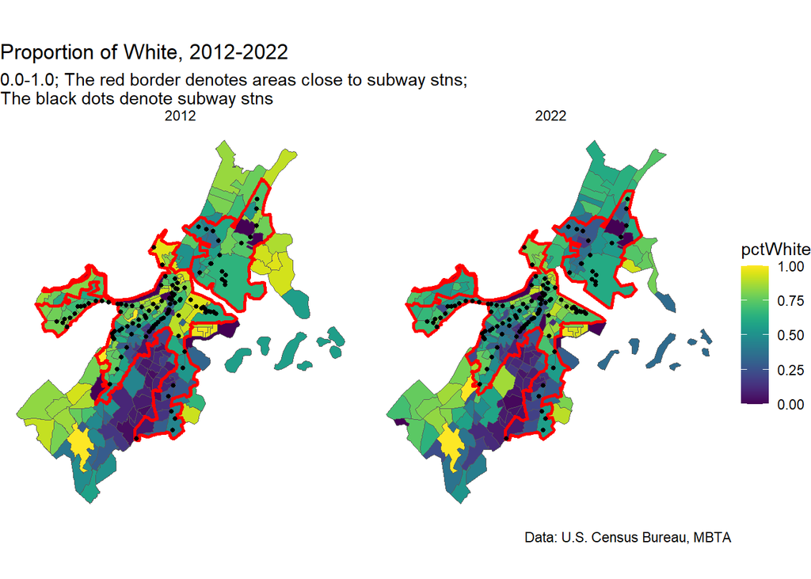

```r
ggplot() +
  geom_sf(data=allTracts.group, aes(fill=pctWhite))+
  geom_sf(data=intersections1222_union, fill='transparent', color='red', lwd = 1)+
    geom_sf(data=MBTA_NODE_CLIP,
          show.legend = "point", size= 1)+
  facet_wrap(~year)+
  scale_fill_viridis()+
  labs(
    title = "Proportion of White, 2012-2022",
    subtitle = "0.0-1.0; The red border denotes areas close to subway stns;\nThe black dots denote subway stns",
    caption = "Data: U.S. Census Bureau, MBTA") +
  theme_void()
```

4. Proportion of Bachelors by Tract, 2012-2022

The figure below shows that the proportion of Bachelors in TOD areas is higher than in non-TOD areas. The proportion of Bachelors in some tracts near subway stations in TOD areas is 10-15%, which is higher than the proportion of Bachelors in the rest of the areas, which is less than 5%. Notably, Chestnut Hill and South Boston areas have decreased in the percentage of college graduates in 2022 compared to 2012. There was no significant difference in Bachelors by year in other regions.

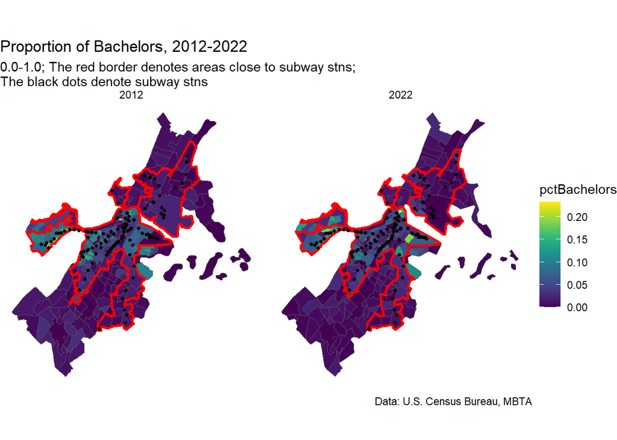

```r
ggplot() +
  geom_sf(data=allTracts.group, aes(fill=pctBachelors))+
  geom_sf(data=intersections1222_union, fill='transparent', color='red', lwd = 1)+
    geom_sf(data=MBTA_NODE_CLIP,
          show.legend = "point", size= 1)+
  facet_wrap(~year)+
  scale_fill_viridis()+
  labs(
    title = "Proportion of Bachelors, 2012-2022",
    subtitle = "0.0-1.0; The red border denotes areas close to subway stns;\nThe black dots denote subway stns",
    caption = "Data: U.S. Census Bureau, MBTA") +
  theme_void()
```

5. Proportion of Poverty by Tract, 2012-2022

The figure below shows that the proportion of Poverty in TOD areas is higher than in non-TOD areas. The proportion of Poverty in some tracts near subway stations in TOD areas is higher than the rest of the areas. There was no significant difference in Poverty by year in other regions.

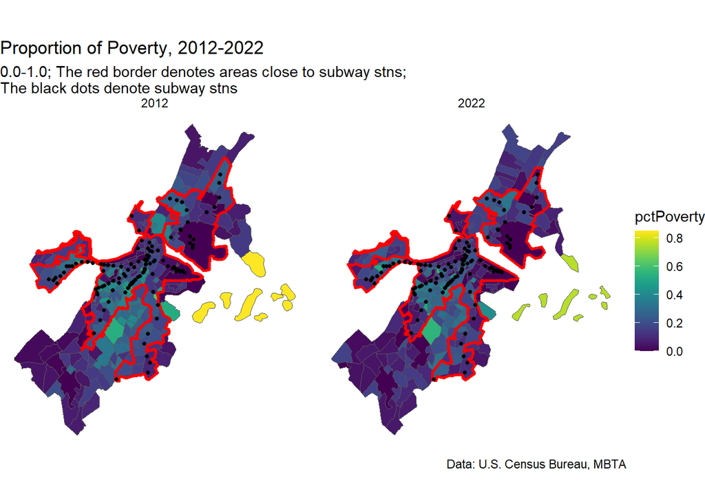

```r
ggplot() +
  geom_sf(data=allTracts.group, aes(fill=pctPoverty))+
  geom_sf(data=intersections1222_union, fill='transparent', color='red', lwd = 1)+
    geom_sf(data=MBTA_NODE_CLIP,
          show.legend = "point", size= 1)+
  facet_wrap(~year)+
  scale_fill_viridis()+
  labs(
    title = "Proportion of Poverty, 2012-2022",
    subtitle = "0.0-1.0; The red border denotes areas close to subway stns;\nThe black dots denote subway stns",
    caption = "Data: U.S. Census Bureau, MBTA") +
  theme_void()
```

## 3. Grouped Bar Plot

This grouped bar plots denote that it has become more difficult to find a house for the same amount of money despite the decrease in population per tract, and this trend appears to be greater in TOD areas than in non-TOD areas. The average values of the proportion of white population, bachelors, and poverty per tract in 2012 and 2022 divided into TOD and Non-TOD areas are as follows. Those values are for reference only as it is an average of proportions and not an average per population or area of tracts.

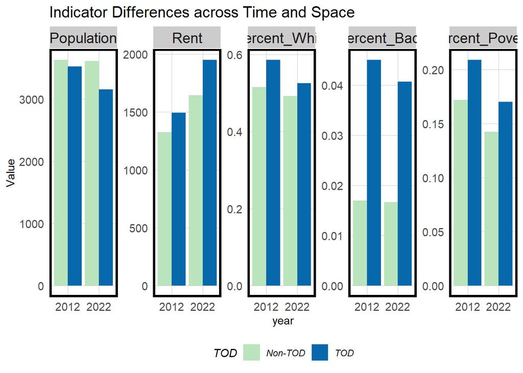

```r
allTracts.Summary <-
  st_drop_geometry(allTracts.group) %>%
  group_by(year, TOD) %>%
  summarize(Rent = mean(MedRent.inf, na.rm = T),
            Population = mean(TotalPop, na.rm = T),
            Percent_White = mean(pctWhite, na.rm = T),
            Percent_Bach = mean(pctBachelors, na.rm = T),
            Percent_Poverty = mean(pctPoverty, na.rm = T))

allTracts.Summary %>%
  gather(Variable, Value, -year, -TOD) %>%
  mutate(Variable = factor(Variable, levels = c("Population", "Rent", "Percent_White", "Percent_Bach", "Percent_Poverty"))) %>%
  ggplot(aes(year, Value, fill= TOD ))+
    geom_bar(stat="identity", position="dodge")+
    facet_wrap(~Variable, scales="free", ncol=5)+
    scale_fill_manual(values=c("#bae4bc","#0868ac"))+
    labs(title="Indicator Differences across Time and Space")+
    plotTheme() + theme(legend.position="bottom",
                        plot.title = element_text(size=15),
      axis.title = element_text(size=11),
      axis.text = element_text(size=11),
      strip.text = element_text(size=8)  # facet 제목 글씨 크기
    )
```

## 4. TOD Indicator Table per Tract

```r
allTracts.Summary %>%
  unite(year.TOD, year, TOD, sep = ": ", remove=T) %>%
  gather(Variable, Value, -year.TOD) %>%
  mutate(Variable = factor(Variable, levels = c("Population", "Rent", "Percent_White", "Percent_Bach", "Percent_Poverty")))%>%
  mutate(Value=round(Value, 2)) %>%
  spread(year.TOD, Value) %>%
  kbl(caption = "TOD Indicator Table per Tract in 2012 and 2022") %>%
  kable_styling(position="center") %>%
  kable_classic(full_width = T, html_font = "Arial")
```

TOD Indicator Table per Tract in 2012 and 2022

| Variable | 2012: Non-TOD | 2012: TOD | 2022: Non-TOD | 2022: TOD |
| --- | --- | --- | --- | --- |
| Population | 3631.44 | 3523.98 | 3611.78 | 3159.46 |
| Rent | 1326.77 | 1491.80 | 1642.60 | 1949.04 |
| Percent_White | 0.52 | 0.59 | 0.49 | 0.53 |
| Percent_Bach | 0.02 | 0.05 | 0.02 | 0.04 |
| Percent_Poverty | 0.17 | 0.21 | 0.14 | 0.17 |

## 5. A Graduated Symbol Map of Population and Median Rent within 0.5 mile of Each Transit Stn

```r
# Calculate Population Density per Tract
allTracts_Dens <- allTracts %>%
  mutate(tractArea=st_area(geometry)) %>%
  mutate(popDens=TotalPop/tractArea) %>%
  mutate(medDens=MedRent/tractArea)

# Calculate Area of Each Buffer
stopBuffer <- stopBuffer %>%
  mutate(bufferArea=st_area(geometry))

# stopBuffer12 <- stopBuffer

# Intersect (To Cut tracts22_Dens by stopBuffer12,
# Loop through each stop and intersect with tracts22_Dens/tracts12_Dens)
stop_results <- data.frame()
hap <- data.frame()
for(i in 1:nrow(stopBuffer)) {
  stop_intersect <- st_intersection(stopBuffer[i,], allTracts_Dens) %>%
    mutate(partArea=st_area(geometry)) %>%
    mutate(partPop = partArea*popDens) %>%
    mutate(partMed = partArea*medDens)
  stop_results <- rbind(stop_results, stop_intersect)
  print(i)
}

hapPop22 <- stop_results %>%
  filter(year %in% "2022")
hapMed22 <- stop_results %>%
  filter(year %in% "2022")
hapPop12 <- stop_results %>%
  filter(year %in% "2012")
hapMed12 <- stop_results %>%
  filter(year %in% "2012")

a <- aggregate(hapPop22$partPop, by=list(hapPop22$STATION), FUN=sum, na.rm=TRUE, na.action=NULL)
colnames(a) <- c("STATION","partVal")
a <- a %>%
  mutate(year="2022") %>%
  mutate(classification="Population by Subway Stn")

b <-aggregate(hapMed22$partMed, by=list(hapMed22$STATION), FUN=sum, na.rm=TRUE, na.action=NULL)
colnames(b) <- c("STATION","partVal")
b <- b %>%
  mutate(year="2022") %>%
  mutate(classification="Median Rent by Subway Stn")

c <-aggregate(hapPop12$partPop, by=list(hapPop12$STATION), FUN=sum, na.rm=TRUE, na.action=NULL)
colnames(c) <- c("STATION","partVal")
c <- c %>%
  mutate(year="2012") %>%
  mutate(classification="Population by Subway Stn")

d <-  aggregate(hapMed12$partMed, by=list(hapMed12$STATION), FUN=sum, na.rm=TRUE, na.action=NULL)
colnames(d) <- c("STATION","partVal")
d <- d %>%
  mutate(year="2012") %>%
  mutate(classification="Median Rent by Subway Stn")

popGraph <- rbind(a,c)
popGraph <- left_join(popGraph,MBTA_NODE, by="STATION")
medGraph <- rbind(b,d)
medGraph <- left_join(medGraph,MBTA_NODE, by="STATION")
```

### 5.1. Map of Population

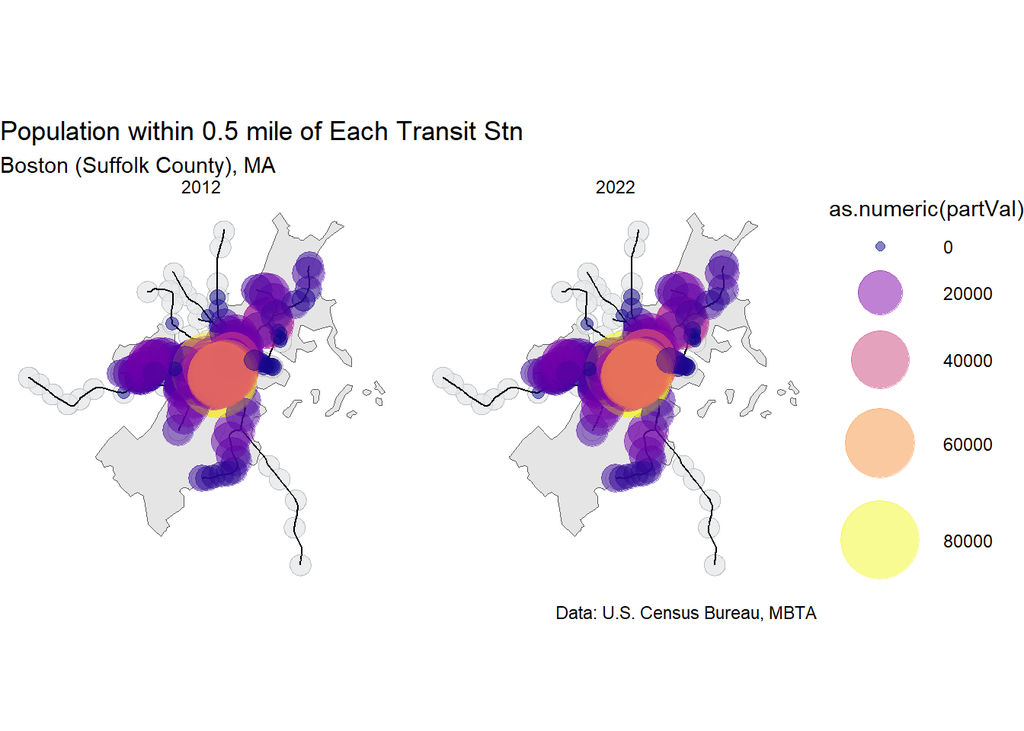

```r
#PLOT for Population 2012-2022
ggplot() +
  geom_sf(data=st_union(tracts22)) +
  geom_sf(data=MBTABuffers, alpha=0.5, fill="#E5E7E9", color = "gray") +
  geom_sf(data=MBTA_ARC, size= 2) +
  geom_point(
    data=popGraph,
    alpha=0.5,
    aes(color=as.numeric(partVal), size = as.numeric(partVal), geometry = geometry),
    stat = "sf_coordinates")+
  facet_wrap(~year)+
  scale_color_viridis(option="C")+
  scale_size_continuous(range=c(2,18))+
  labs(title="Population within 0.5 mile of Each Transit Stn",
       subtitle="Boston (Suffolk County), MA",
       caption="Data: U.S. Census Bureau, MBTA") +
  guides(color = guide_legend("as.numeric(partVal)"), size = guide_legend("as.numeric(partVal)")) +
  theme_void()+
  theme(legend.position = "right")
```

### 5.2. Map of Median Rent

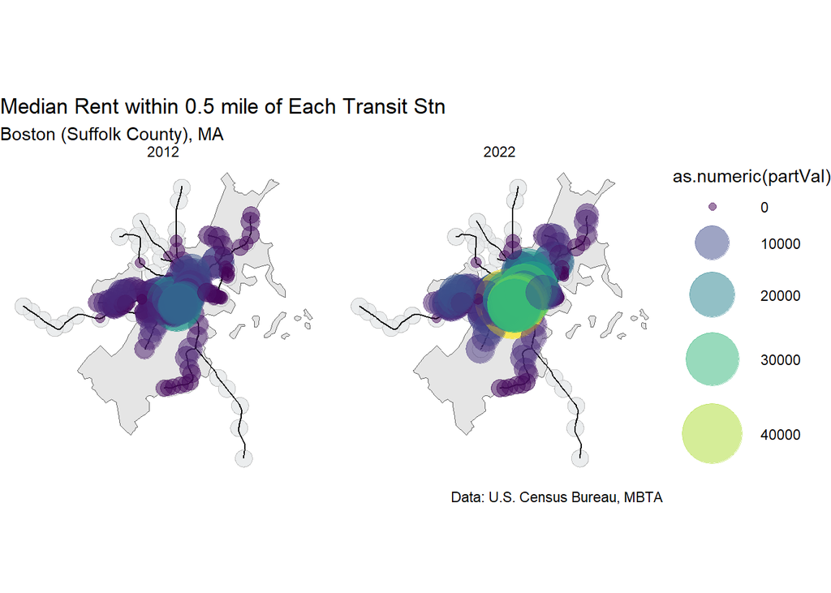

```r
#PLOT for Median Rent 2012-2022
ggplot() +
  geom_sf(data=st_union(tracts22)) +
  geom_sf(data=MBTABuffers, alpha=0.5, fill="#E5E7E9", color = "gray") +
  geom_sf(data=MBTA_ARC, size= 2) +
  geom_point(
    data=medGraph,
    alpha=0.5,
    aes(color=as.numeric(partVal), size = as.numeric(partVal), geometry = geometry),
    stat = "sf_coordinates")+
  facet_wrap(~year)+
  scale_color_viridis(option="D")+
  scale_size_continuous(range=c(2,18))+
  labs(title="Median Rent within 0.5 mile of Each Transit Stn",
       subtitle="Boston (Suffolk County), MA",
       caption="Data: U.S. Census Bureau, MBTA") +
  guides(color = guide_legend("as.numeric(partVal)"), size = guide_legend("as.numeric(partVal)")) +
  theme_void()+
  theme(legend.position = "right")
```

[figure not shown]

```r
allTracts.rings <-
  st_join(
    st_centroid(dplyr::select(allTracts, GEOID, year)),
    multipleRingBuffer(st_union(MBTA_NODE), 14484, 805)) %>%
  st_drop_geometry() %>%
  left_join(dplyr::select(allTracts, GEOID, MedRent, year),
            by=c("GEOID"="GEOID", "year"="year")) %>%
  st_sf() %>%
  mutate(distance=distance/1609)

ggplot() +
  geom_sf(data=allTracts.rings, aes(fill=distance))+
  geom_sf(data=intersections1222_union, fill='transparent', color='red', lwd = 1)+
    geom_sf(data=MBTA_NODE_CLIP,
          show.legend = "point", color='white', size= 1)+
  facet_wrap(~year)+
  scale_fill_viridis()+
  labs(
    title = "Distance to Subway Stns, 2012-2022",
    subtitle = "0.0-1.0; The red border denotes areas close to subway stns;\nThe white dots denote subway stns",
    caption = "Data: U.S. Census Bureau, MBTA") +
  theme_void()
```

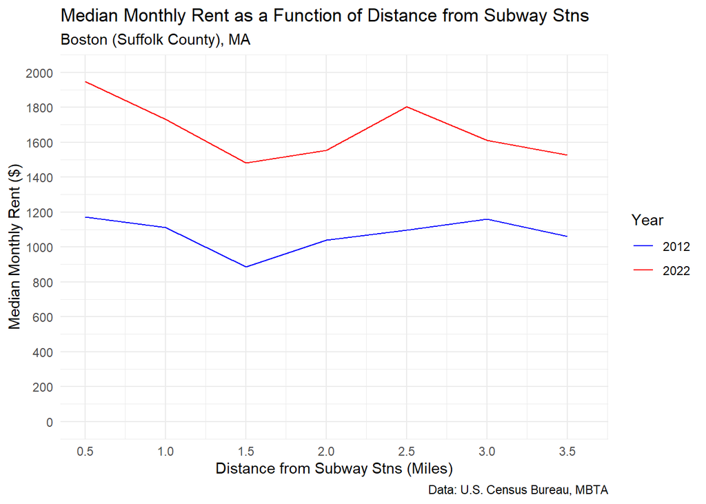

```r
MedRent_sum22 <- allTracts.rings %>%
  filter(year %in% "2022", !is.na(MedRent)) %>%
  group_by(distance) %>%
  summarize(mean_value = mean(MedRent)) %>%
  mutate(year=2022)

MedRent_sum12 <- allTracts.rings %>%
  filter(year %in% "2012", !is.na(MedRent)) %>%
  group_by(distance) %>%
  summarize(mean_value = mean(MedRent)) %>%
  mutate(year=2012)

MedRent_sum <- rbind(MedRent_sum22,MedRent_sum12)


#MedRent_mean <- aggregate(MedRent ~ distance, data = allTracts.rings, FUN = mean, na.rm=TRUE, na.action=NULL)
MedRent_sum$year <- as.factor(MedRent_sum$year)
ggplot(MedRent_sum, aes(x = distance, y = mean_value, group=year, color=year)) +
  geom_line() +
  scale_x_continuous(limits = c(0.5, 3.6), breaks = seq(0.5, 3.6, by = 0.5)) +
  scale_y_continuous(limits = c(0, 2000), breaks = seq(0, 2000, by = 200)) +
  scale_color_manual(values = c("2022" = "red", "2012" = "blue"))+
labs(
    title = "Median Monthly Rent as a Function of Distance from Subway Stns",
    subtitle = "Boston (Suffolk County), MA",
    caption = "Data: U.S. Census Bureau, MBTA",
    x="Distance from Subway Stns (Miles)",
    y="Median Monthly Rent ($)",
    color = "Year") +
  theme_minimal()
```

# Conclusion: